# 2 ACTION

Damilare Olaleye

9/12/2019

1. What geom would you use to draw a line chart? A boxplot? A histogram? An area chart?

Answer:

Line chart : geom_path()/geom_line() Boxplot : geom_boxplot() Histogram ; geom_histogram() Area Chart : geom_area()

2. Run this code in your head and predict what the output will look like. Then, run the code in R and check your predictions:

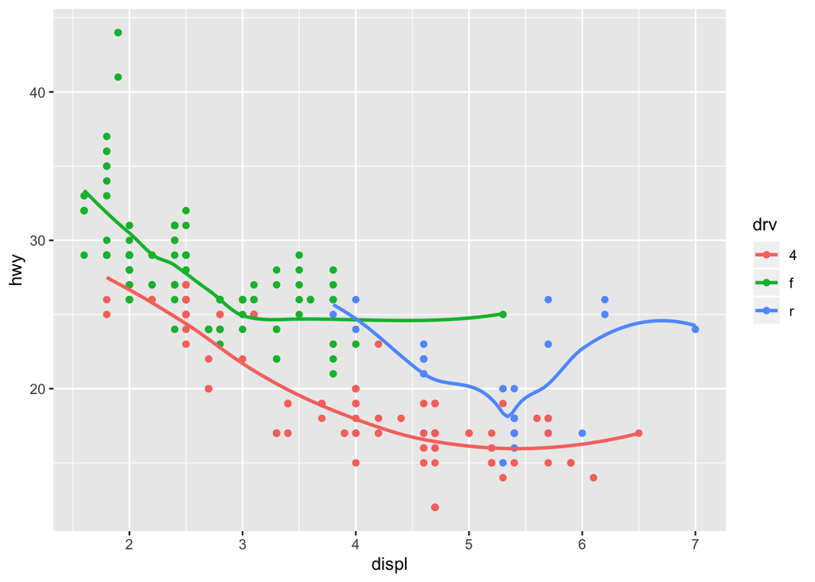

```r
library(tidyverse)
ggplot(
data = mpg,
mapping = aes(x = displ, y = hwy, color = drv)
) +
geom_point() +
geom_smooth(se = FALSE)
```

Answer: The code would produce a scatterplot with a rough line that goes through the points. The x axis is displ and y is hwy, and the points and the lines are of different colors based on the categories of drv.

3. What does show.legend = FALSE do? What happens if you remove it? Why do you think I used it earlier in the chapter?

Answer: Legend specifies what the elements in a graph represents. For instance, different colors in a line graph could represent different entities and the names/labels of those are shown on the side of the graph as graph legend. So, setting show.legend = FALSE would hide this information. Using legend is helpful as it makes the elements in a graph more informational. Legend explains the mapping between levels and values.

4. What does the se argument to geom_smooth() do?

Answer: According to the documentation, se stands for smooth edges. se adds error bands to the lines.

5. Will these two graphs look different? Why/why not?

ggplot(data = mpg, mapping = aes(x = displ, y = hwy)) + geom_point() + geom_smooth()

ggplot() + geom_point( data = mpg, mapping = aes(x = displ, y = hwy) ) + geom_smooth( data = mpg, mapping = aes(x = displ, y = hwy) )

Answer: The two graphs will look the same.

On the the first ggplot execution, the arguments inside of ggplot uses the data mpg, maps x and y to displ and hwy respectively. The addition of geom_point() and geom_smooth specifies which graphs to use in the execution.

The second ggplot execution specifies the arguments and the mapping inside of geom_point and geom_smooth which results in the same graph as the one above as all the mapping and the data used is same as the first one.

6. Re-create the R code necessary to generate the following graphs.

Answer:

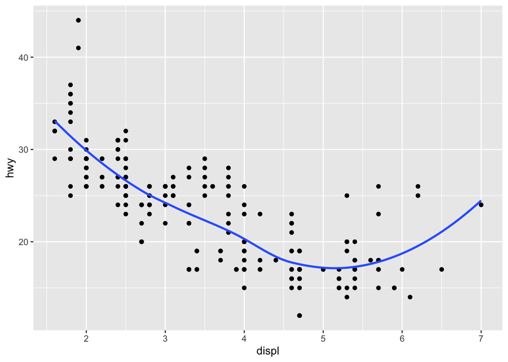

```r
ggplot(data = mpg, aes(x = displ, y = hwy)) + geom_point() + geom_smooth(se = FALSE)
```

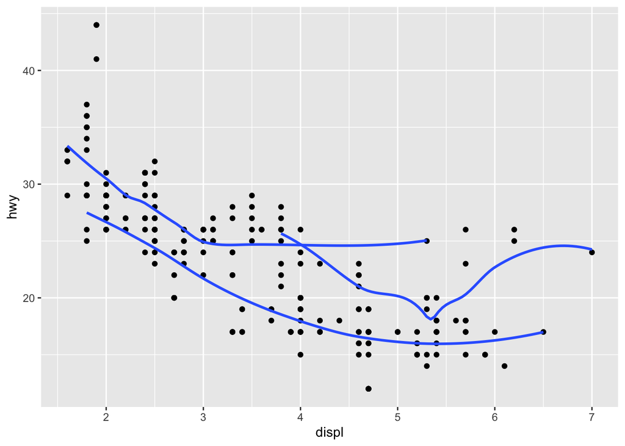

```r
ggplot(data = mpg, aes(x = displ, y = hwy)) + geom_point() + geom_smooth(se = FALSE, mapping = aes(group = drv))
```

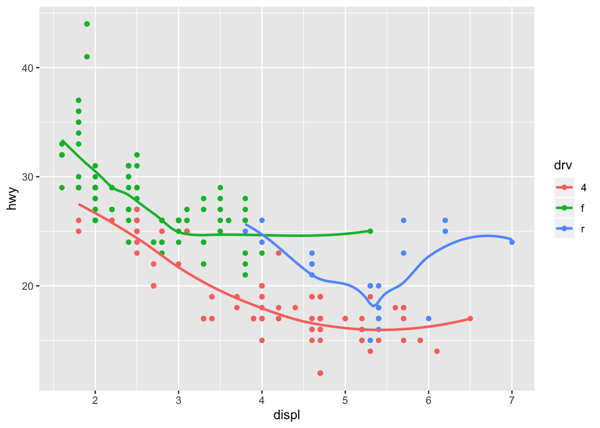

```r
ggplot(data = mpg, aes(x = displ, y = hwy, color = drv)) + geom_point() + geom_smooth(se = FALSE)
```

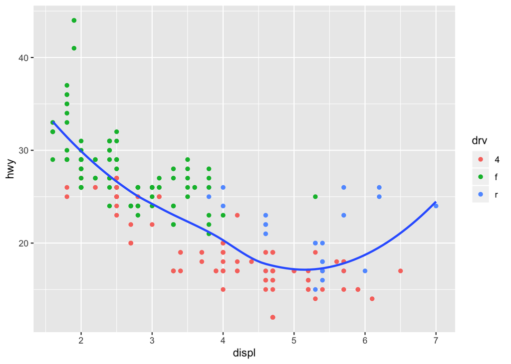

```r
ggplot(data = mpg, aes(x = displ, y = hwy)) + geom_point(mapping = aes(color = drv)) + geom_smooth(se = FALSE)
```

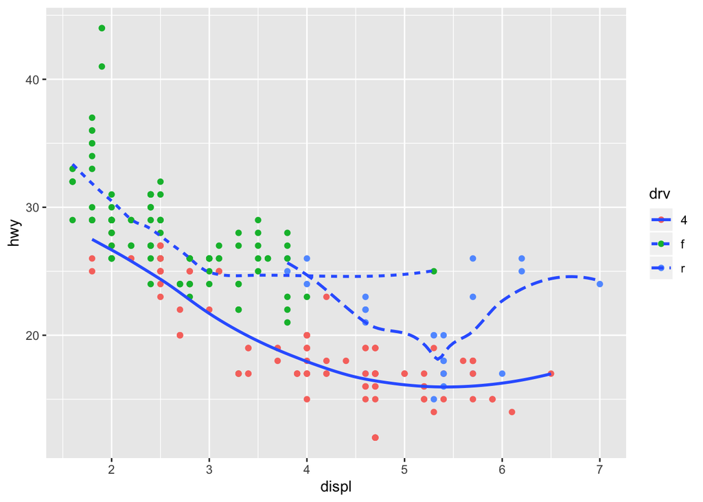

```r
ggplot(data = mpg, aes(x = displ, y = hwy)) + geom_point(mapping = aes(color = drv)) + geom_smooth(se = FALSE, aes(linetype = drv))
```

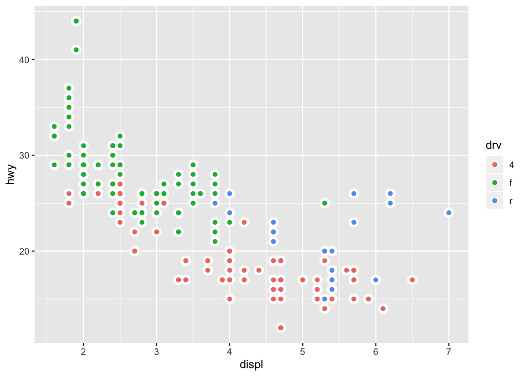

```r
  ggplot(data = mpg, aes(x = displ, y = hwy)) + geom_point(color = "white", size = 4) + geom_point(aes(color = drv))
```